# Clustering

# Task 2

```r
library(tidyverse)
```

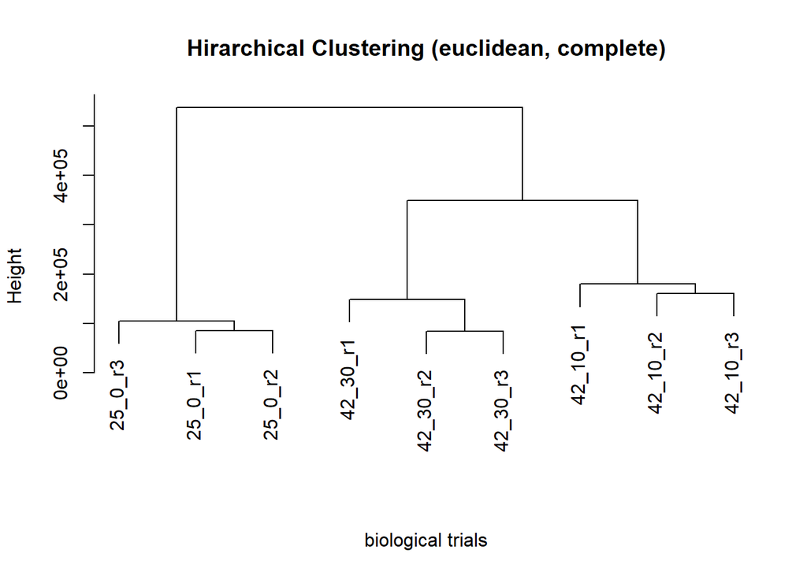

```r
yeast_data <- read_csv("basic_yeast_heatshock.csv")
expression_matrix <- yeast_data %>% column_to_rownames(var =  "gene_id")

distance_matrix_euclidean <- dist(t(expression_matrix), method = "euclidean")

hc_complete <- hclust(distance_matrix_euclidean, method = "complete")

plot(hc_complete,
     main = "Hirarchical Clustering (euclidean, complete)", xlab = "biological trials", sub = "")
```

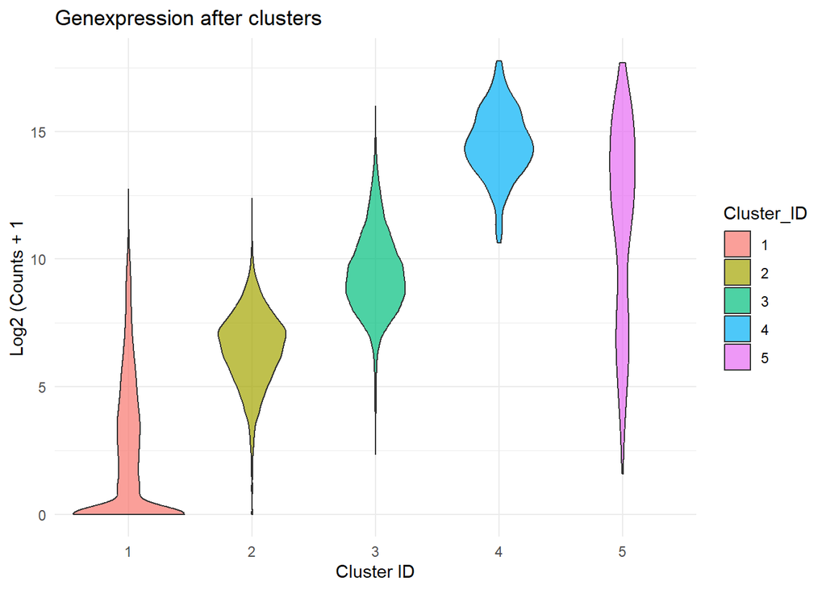

```r
log_counts <- log2(expression_matrix + 1)
gene_dist <- dist(log_counts, method = "euclidean")
gene_hc <- hclust(gene_dist, method = "complete")
num_clusters <- 5
gene_clusters <- cutree(gene_hc, k = num_clusters)

violin_data <- log_counts %>% rownames_to_column(var = "gene_id") %>% mutate(Cluster_ID = as.factor(gene_clusters)) %>% pivot_longer(cols = starts_with("25_") | starts_with("42_"), names_to = "Sample", values_to = "Log_Expression")

ggplot(violin_data, aes(x = Cluster_ID, y = Log_Expression, fill = Cluster_ID)) +
       geom_violin(alpha = 0.7) +
         labs(title = "Genexpression after clusters", x = "Cluster ID", y = "Log2 (Counts + 1") + theme_minimal()
```

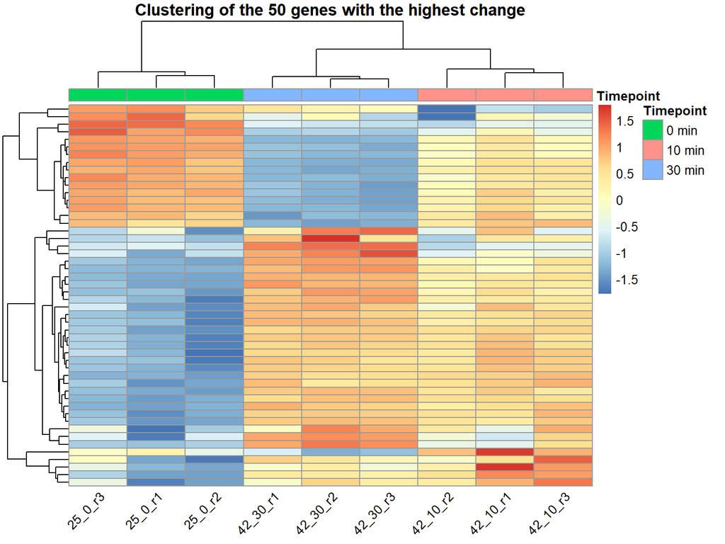

```r
library(pheatmap)
top50_changing_data <- yeast_data %>% mutate(mean_0min = (`25_0_r1` + `25_0_r2` + `25_0_r3`) / 3, mean_10min = (`42_10_r1` + `42_10_r2` + `42_10_r3`) / 3, mean_30min = (`42_30_r1` + `42_30_r2` + `42_30_r3`) / 3) %>% mutate(diff_10_vs_0 = abs(mean_10min - mean_0min), diff_30_vs_10 = abs(mean_30min - mean_10min)) %>% mutate(max_change = pmax(diff_10_vs_0, diff_30_vs_10)) %>% slice_max(order_by = max_change, n = 50) %>% select(gene_id, starts_with("25_"), starts_with("42_"))

heatmap_matrix <- top50_changing_data %>% column_to_rownames(var = "gene_id")
heatmap_matrix_log <- log2(heatmap_matrix + 1)
sample_info <- data.frame(Timepoint = c("0 min", "0 min", "0 min", "10 min", "10 min", "10 min", "30 min", "30 min", "30 min"))
rownames(sample_info) <- colnames(heatmap_matrix_log)

pheatmap(heatmap_matrix_log,
         scale = "row",
         annotation_col = sample_info,
         clustering_distance_rows = "euclidean",
         clustering_distance_cols = "euclidean",
         clustering_method = "complete",
         show_rownames = FALSE,
         angle_col = 45,
         main = "Clustering of the 50 genes with the highest change")
```

# Task 3

Yes, we need to filter out genes that have a value of zero across all samples (i.e., were not measured at all). Since they do not change at all, they have no variance and would cause errors during the mathematical calculation (division by the standard deviation).

Yes, scaling is absolutely crucial! Biological systems contain highly expressed genes (such as housekeeping genes) with expression levels in the tens of thousands. At the same time, there are regulatory genes with values below 50 that may quadruple under stress. Without scaling, the PCA would ultimately measure only the absolute abundance of those highly expressed genes. Scaling (setting the mean to 0 and variance to 1) ensures that the relative change of every single gene is mathematically weighted equally.

```r
library(broom)
```

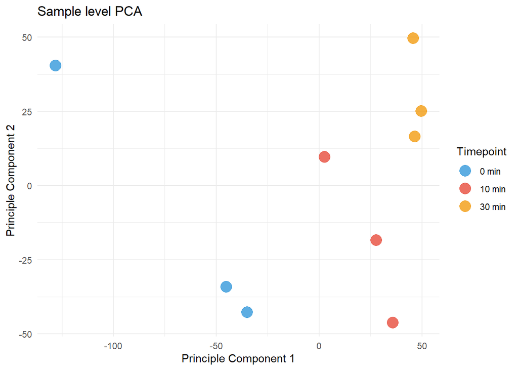

```r
yeast_long <- yeast_data %>% filter(rowSums(select(., starts_with("25_") | starts_with("42_"))) > 0) %>% pivot_longer(cols = starts_with("25_") | starts_with("42_"), names_to = "Sample", values_to = "Expression")

pca_results <- yeast_long %>% nest(data = everything()) %>% mutate(pca = map(data, ~prcomp(.x %>% pivot_wider(names_from = gene_id, values_from = Expression) %>% select(-Sample), center = TRUE, scale. = TRUE)), augmented = map2(pca, data, ~augment(.x, data = .y %>% pivot_wider(names_from = gene_id, values_from = Expression))))

pca_plot_data <- pca_results %>% unnest(augmented) %>% select(Sample, .fittedPC1, .fittedPC2) %>% mutate(Timepoint = case_when(str_starts(Sample, "25_0") ~ "0 min",
                             str_starts(Sample, "42_10") ~ "10 min",
                             str_starts(Sample, "42_30") ~ "30 min"))

ggplot(pca_plot_data, aes(x = .fittedPC1, y = .fittedPC2, color = Timepoint)) +
  geom_point(size = 5, alpha = 0.8) +
  labs(title = "Sample level PCA",
       x = "Principle Component 1",
       y = "Principle Component 2") + theme_minimal() +
  scale_color_manual(values = c("0 min" = "#3498db", "10 min" = "#e74c3c", "30 min" = "#f39c12"))
```

```r
library(ggrepel)
```

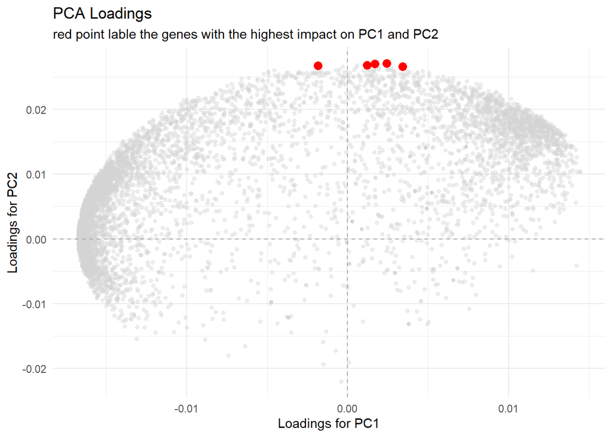

```r
pca_loadings <- pca_results %>% mutate(tidy_loadings = map(pca, ~tidy(.x, matrix = "rotation"))) %>% unnest(tidy_loadings) %>% select(column, PC, value) %>% pivot_wider(names_from = PC, names_prefix = "PC", values_from = value)

top_loadings_genes <- pca_loadings %>% mutate(distance_from_zero = PC1^2 + PC2^2) %>% slice_max(order_by = distance_from_zero, n = 5) %>% pull(column)
pca_loadings <- pca_loadings %>% mutate(label = if_else(column %in% top_loadings_genes, column, ""))

ggplot(pca_loadings, aes(x = PC1, y = PC2)) + geom_point(color = "lightgrey", alpha = 0.4, size = 1.2) + geom_point(data = filter(pca_loadings, label != ""), color = "red", size = 3) + geom_text_repel(aes(label = label), box.padding = 1.2, point.padding = 0.4, force = 30, direction = "both", segment.color = "grey30", segment.size = 0.4, size = 3.5, fontface = "bold") +
  geom_hline(yintercept = 0, linetype = "dashed", color = "darkgrey") +
  geom_vline(xintercept = 0, linetype = "dashed", color = "darkgrey") +
  labs(title = "PCA Loadings", x = "Loadings for PC1", y = "Loadings for PC2", subtitle = "red point lable the genes with the highest impact on PC1 and PC2") + theme_minimal()
```

```r
# Log Transformation and long format
yeast_log_profiles <- yeast_data %>%
  filter(gene_id %in% top_loadings_genes) %>%
  mutate(across(starts_with("25_") | starts_with("42_"), ~ log2(.x + 1))) %>%
  pivot_longer(
    cols = starts_with("25_") | starts_with("42_"),
    names_to = "Sample",
    values_to = "Log2_Expression"
  ) %>%
  mutate(
    Timepoint = case_when(
      str_starts(Sample, "25_0") ~ "0 min",
      str_starts(Sample, "42_10") ~ "10 min",
      str_starts(Sample, "42_30") ~ "30 min"
    ),
    Timepoint_Num = case_when(
      Timepoint == "0 min" ~ 0,
      Timepoint == "10 min" ~ 10,
      Timepoint == "30 min" ~ 30
    )
  )

# Separate Tabelle für die Mittelwerte (für den Linienplot)
yeast_log_means <- yeast_log_profiles %>%
  group_by(gene_id, Timepoint_Num, Timepoint) %>%
  summarize(Mean_Log2 = mean(Log2_Expression), .groups = "drop")
```

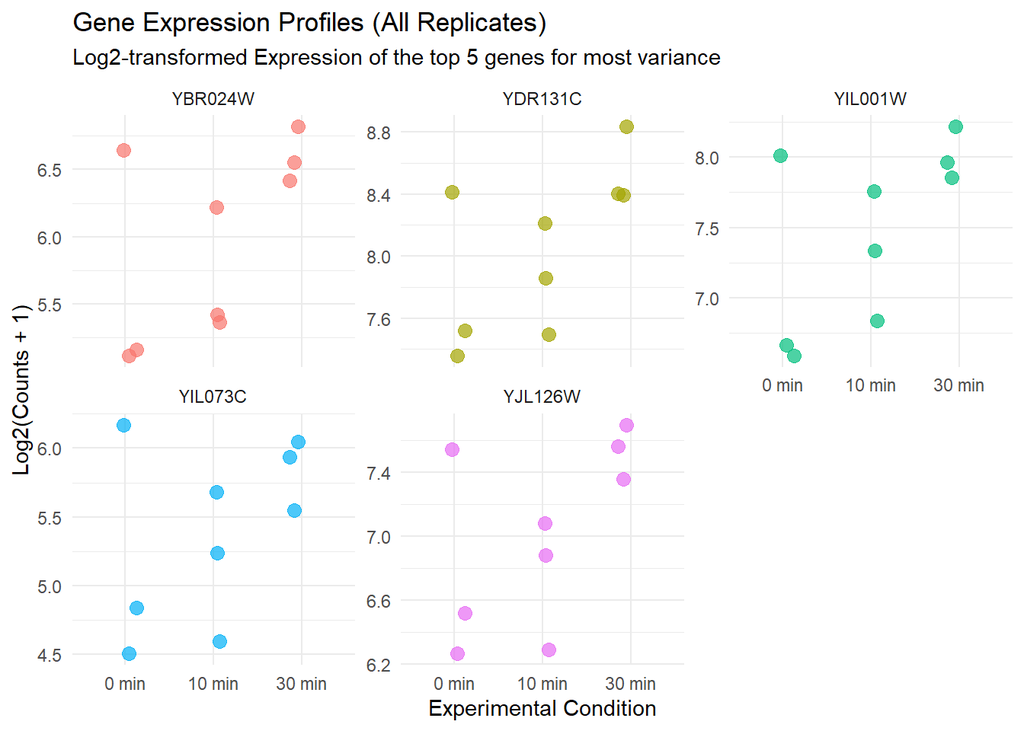

```r
ggplot(yeast_log_profiles, aes(x = Timepoint, y = Log2_Expression, color = gene_id)) +
  geom_jitter(width = 0.15, size = 3, alpha = 0.7) +
  facet_wrap(~gene_id, scales = "free_y") +
  labs(
    title = "Gene Expression Profiles (All Replicates)",
    subtitle = "Log2-transformed Expression of the top 5 genes for most variance",
    x = "Experimental Condition",
    y = "Log2(Counts + 1)",
    color = "Gene ID"
  ) +
  theme_minimal() +
  theme(legend.position = "none") # Legende weglassen, da Facets beschriftet sind
```

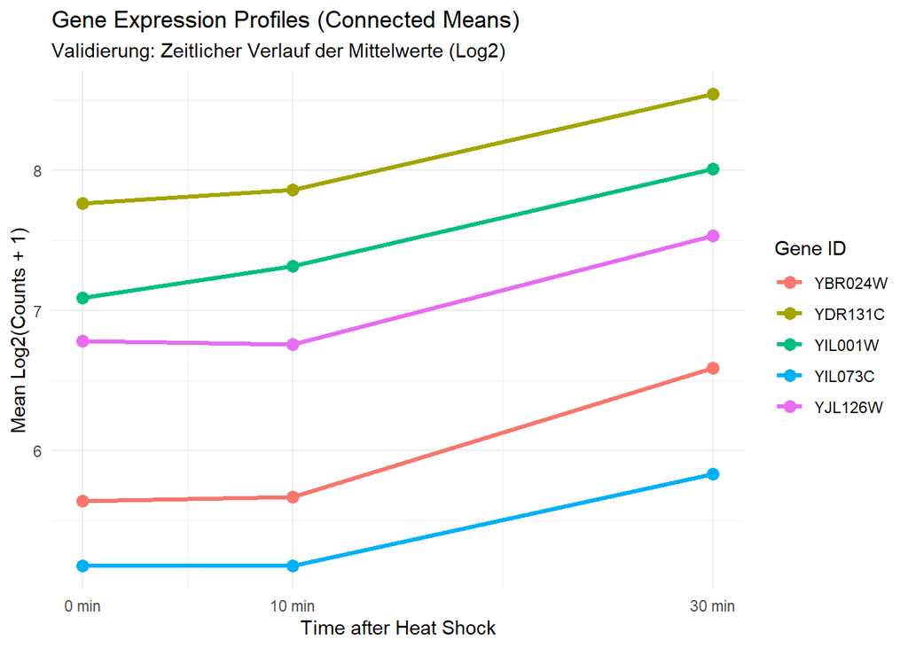

```r
ggplot(yeast_log_means, aes(x = Timepoint_Num, y = Mean_Log2, color = gene_id, group = gene_id)) +
  geom_line(linewidth = 1.2) +
  geom_point(size = 3) +
  scale_x_continuous(breaks = c(0, 10, 30), labels = c("0 min", "10 min", "30 min")) +
  labs(
    title = "Gene Expression Profiles (Connected Means)",
    subtitle = "Validierung: Zeitlicher Verlauf der Mittelwerte (Log2)",
    x = "Time after Heat Shock",
    y = "Mean Log2(Counts + 1)",
    color = "Gene ID"
  ) +
  theme_minimal()
```